# ISON

Idil YILDIZ

12/21/2021

## Introduction

In this exercise, I assess causal factors that might play a role in creating the Preferential Trade Agreements (PTA) between countries by testing the arguments of Manger and Pickup(2012). Authors argue that the number of PTAs signed by the governments and the countries’ overall democracy scores have a causal relationship. However, there are some problems with this claim. First, these two variables are endogenous. An increase in countries’ democracy scores raises their probability of signing PTAs. But also, PTAs increase the democracy scores of the countries.

Second, mainstream statistical models look only at the correlation patterns between the number of PTAs and Democracy scores of the countries. It underestimates the network-related causal mechanisms that might play a role in this correlation. Moreover, mainstream statistical analysis underestimates the nature of the evolution of both variables; namely, they do not discuss whether the behavior of the states evolve through selection or influence.

To overcome the limitations of the structural equation models through SOAM, I am using the Rsiena framework in this analysis. RSiena considers potential mechanisms mentioned above and estimates the effects of actor covariates, dyadic covariates, and network structure covariates. Actor covariates are the characteristics of the individual countries (Democracy, GDP) and dyadic covariates are the estimates of each pair of countries (Distance, Alliance, and Trade). The network structure covariates define the structural position of the countries within the network (degree, transitivity).

According to the literature and the model presented above, I construct the following hypothesis:

H1: Governments prefer to sign PTAs with similar regime types (Selection Hypothesis)

H2: Countries democracy score influenced by their PTA partners (Influence Hypothesis)

H3: As democracy scores of countries increase, their probability of signing PTAs increases accordingly.

## Data

For this analysis, I am using the database which can be accessed through this link: https://dataverse.harvard.edu/dataset.xhtml?persistentId=doi:10.7910/DVN/TMIIW1 ). Analysis covers the period from 1994 to 2004 so that global financial crisis and cold war effects are isolated.

The dataset constructed by the authors has 145 nodes (countries). European countries are coded as one node since the Commission of European Communities negotiates PTAs for all members. There are no “structural zeros” because, during the period I focus, no new countries have emerged. The missing information (NA) is not more than 10 %; therefore, they do not bias the estimates.

## Descriptive Statistics

According to the graphs presented below, we can see that the number of countries that signed PTAs increased significantly. In addition, we can also see an increase in the Democracy Scores of the countries observed.

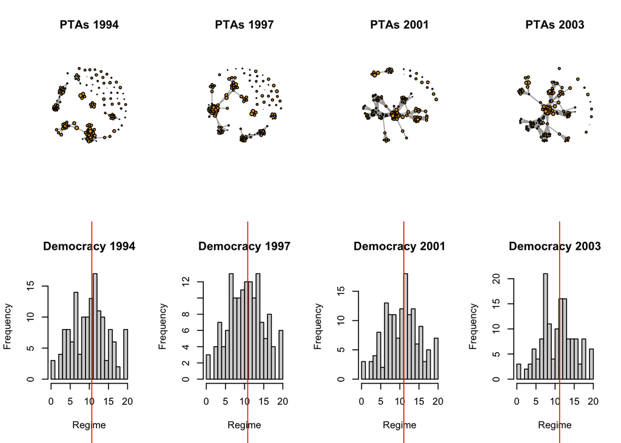

The graphs presented below show that countries’ GDP increased in parallel to the democracy scores. This can cause a problem of multicollinearity and consequently problematic fit for the model.

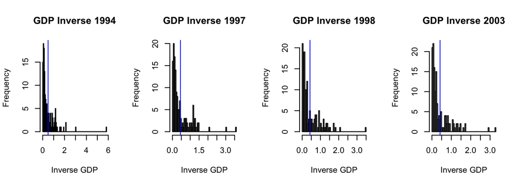

## Model Specifications

In SAOM models, actors are presumed to be rational and strategic. Actors act independently and one at a time. The subsequent changes, called mini-steps, induce a dynamic and endogenous context. The actors’ dependence over time (primarily through reciprocation and transitive closure; one tie may cause another) signals substantial dependence.

The change is decomposed into two sub-models. First, there is the “rate function,” and the second is the “objective function”. At a randomly determined moment t, actor i have an opportunity to change a tie variable $X_{ij}$; mini-step. It follows the following function:

$$g_i(t)= \lambda e^{-\lambda t}, t >0$$

When a mini-step is taken, the probability distribution of the result of this mini-step depends on the objective function, which means the probability of deciding on a specific change to make (direction of the change) . For example, the function for networks is represented below:

$$f_i^{t} (\beta, x,z) = \sum_{k=1}^{n_1}\beta_k^{x} s_{ik}^{x} (x,z)$$

The function for behavior represented below:
$$f_i^{z} (\beta, x,z) = \sum_{k=1}^{n_2}\beta_k^{z} s_{ik}^{z} (x,z)$$
Notation used in the formulas: $x$ represents tie, $z$ behavior, $\beta_k^{z}$ and $\beta_k^{x}$ represents the importance of the effects ($s_{ik}^{z}$ and $s_{ik}^{x}$ ; which can be related to networks structure, dyadic covariates an country covariates chosen by the researchers.)

However, since the model itself is simulated through the mini-steps calculated through the rate function, actors are also considered to be myopic. The results that we obtain are exponentiated coefficients from the network objective function that will be interpreted as the multiplicative increase in the probability of a given tie.

## Results

```r
ans5
```

```
## Estimates, standard errors and convergence t-ratios
##
##                                            Estimate   Standard   Convergence
##                                                         Error      t-ratio
## Network Dynamics
##    1. rate constant PTAs rate (period 1)    0.7594  ( 0.0919   )    0.0404
##    2. rate constant PTAs rate (period 2)    0.2051  ( 0.0456   )    0.0157
##    3. rate constant PTAs rate (period 3)    0.3400  ( 0.0612   )    0.0135
##    4. rate constant PTAs rate (period 4)    1.1874  ( 0.1175   )    0.0329
##    5. rate constant PTAs rate (period 5)    0.5543  ( 0.0829   )   -0.0128
##    6. rate constant PTAs rate (period 6)    0.9131  ( 0.1060   )    0.0320
##    7. rate constant PTAs rate (period 7)    0.6712  ( 0.0818   )   -0.0025
##    8. rate constant PTAs rate (period 8)    0.4342  ( 0.0612   )   -0.0570
##    9. rate constant PTAs rate (period 9)    0.2337  ( 0.0441   )   -0.0027
##   10. eval degree (density)                -5.4883  ( 0.6504   )    0.0617
##   11. eval transitive triads                1.8757  ( 0.4013   )    0.0327
##   12. eval number of actor pairs at dist 2 -0.0999  ( 0.0288   )    0.0092
##   13. eval Distance                        -0.0311  ( 0.0055   )   -0.0736
##   14. eval Allies                           1.0214  ( 0.5056   )    0.0148
##   15. eval Trade                            0.0821  ( 0.0173   )   -0.0567
##   16. eval Democracy ego                   -0.5754  ( 0.4909   )   -0.0459
##   17. eval Democracy ego x Democracy alter  0.0573  ( 0.0104   )    0.0238
##   18. eval GDP_inv ego                     -3.9940  ( 2.4518   )    0.0537
##   19. eval GDP_inv ego x GDP_inv alter      0.3423  ( 0.4486   )    0.0611
##   20. eval int.  Trade x GDP_inv alter      0.1462  ( 0.0301   )    0.0442
##
## Behavior Dynamics
##   21. rate rate Democracy (period 1)        0.4629  ( 0.0794   )    0.0188
##   22. rate rate Democracy (period 2)        0.6507  ( 0.1085   )    0.0846
##   23. rate rate Democracy (period 3)        0.3272  ( 0.0700   )    0.0101
##   24. rate rate Democracy (period 4)        0.5196  ( 0.1027   )    0.0284
##   25. rate rate Democracy (period 5)        1.0154  ( 0.1459   )   -0.0371
##   26. rate rate Democracy (period 6)        1.3802  ( 0.1719   )   -0.0123
##   27. rate rate Democracy (period 7)        1.1071  ( 0.1655   )   -0.0077
##   28. rate rate Democracy (period 8)        0.5353  ( 0.0937   )    0.0167
##   29. rate rate Democracy (period 9)        0.4104  ( 0.0770   )   -0.0414
##   30. eval Democracy linear shape           0.1320  ( 0.0460   )    0.0270
##   31. eval Democracy quadratic shape       -0.0278  ( 0.0077   )   -0.0214
##   32. eval Democracy average alter          0.0595  ( 0.0216   )   -0.0245
##
## Overall maximum convergence ratio:    0.2111
##
##
##  Model Type:
## PTAs : Initiative model
##
##
## Total of 2146 iteration steps.
```

The highest odd ratios in the model primarily depend on the network structure itself. The density parameter signifies that the utility of making ties is negative in the model. Also, the Transitive triad parameter is significant and the estimate is positive, which means that if a country forms PTA with two other countries, these two countries will also form PTAs. Lastly,in this network countries avoid being indirectly tied to the other countries is reflected in the “number of actor pairs at distance two”.

Democracy ego is negative and statistically insignificant on PTA formation. This helps us to refute hypothesis 3. However, countries tend to form alliances with other countries with similar democracy scores, which is reflected in the parameter Democracy ego x Democracy alter (Evidence for H1). Democracy average variable is positive and statistically significant; it tells us that alter increases its democracy score after establishing a tie with ego through PTA. This is evidence for H2.

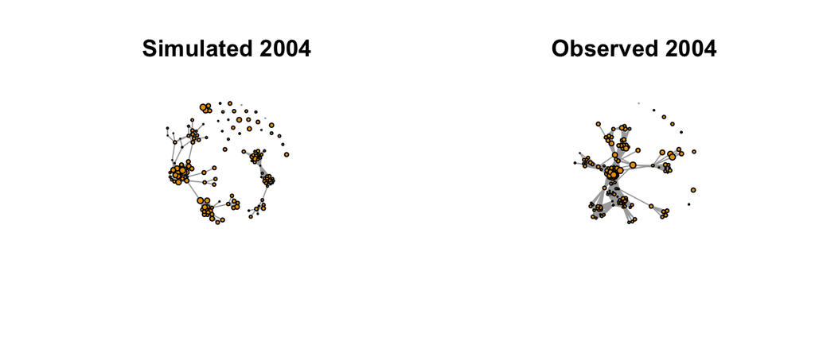

The Goodness of Fit (GOF) Statistics are presented below:

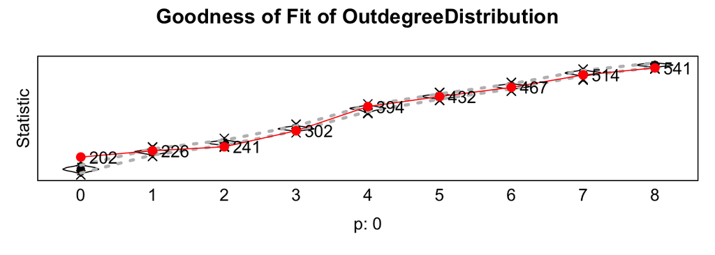

```
## Note: some statistics are not plotted because their variance is 0.
## This holds for the statistic: 20.
```

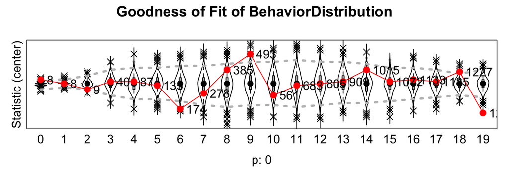

## Conclusion

There is some evidence that countries chose to establish PTAs with countries with similar democracy scores (selection on homophily). And countries that sign PTA’s average democracy score increases for the alters (influnce hypothesis). However, there is no clear evidence shows us that an increase in the democracy score leads countries to sign PTAs. To have more robust evidence and to have more precise results, we need to find solutions for the model fit. The possible multicollinearity can be the main problem for GOF, and correcting for it can help us to correct the problmatic model fit.